# The Birthday Paradox

Vassilis Markos

# The Birthday Paradox

The “Paradox” goes like that:

> In a room of $n$ people what is the minimum value of $n$ such that at least two people in that room share birthdays?

## Some Initial Thoughts

To begin with, $n=1$ is not the answer, since a single person cannot share birthday with anybody else in the room. In the same way, we should not consider values of $n$ greater than 365, assuming no leap years for a moment. So, we are left with:

$$n\in\{2,3,\ldots,365\}.$$

## A Simulation

We can simulate a room of $n$ people as a list of $n$ numbers ranging from 1 up to 365, with each number corresponding to the day each person has been born. So, whenever we have a sample containing at least one pair of duplicates, we have two people in that room sharing birthday.

Now, in order to actually estimate the corresponding probability, we just have to repeat the above many times.

```
bday_simulation <- function() {
  N <- 100
  for (n in 2:365) {
    hits <- 0
    for (i in 1:N) {
      room <- sample(1:365, n, replace = TRUE)
      dedup <- unique(room)
      if (length(dedup) < length(room)) {
        # This means there are some duplicates, so some people share birthday
        hits <- hits + 1
      }
    }
    prob_same_bday = hits / N
    if (prob_same_bday > 0.50) {
      return(n)
    }
  }
  return(366)
}
results <- c() # c() constructs an empty vector (column)
for (i in 1:100) {
  results[i] <- bday_simulation()
}
res_table <- table(results)
print(res_table)
```

```
results
19 20 21 22 23 24 25
 1  3  6 28 29 23 10
```

```
barplot(res_table)
```

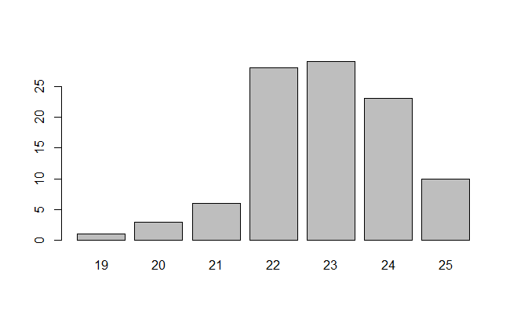

## Probabilistic Reasoning

So, we want the probability that two out of $n$ people in a room share birthday for some $n=2,3,4\ldots,365$. It is easier to compute the probability that no two people share birthday in a room, i.e., that among the $n$ people we can find $n$ different birthdays. We can think of this as a process of choosing $n$ (pairwise) different dates among the 365 days of the year. So:

- For the first person, we have 365 days to choose from.
- For the second person, we have $365-1=364$ choices, since one day has been assigned to the first person.
- For third person, we have $365-2=363$ days…
- …and so on and so forth.
- For the $n$-th person, we have $365-(n-1)=365-n+1$.

So, in total, we have:

$$365\cdot364\cdots(365-n+1)$$
different dates combinations in which $n$ people do not share birthday. In total, we have:

$$\underbrace{365\cdot365\cdots
365}_n=365^n$$
possible dates combinations, so, the probability of two people in a room of $n$ people not sharing birthday is exactly:

$$\frac{365\cdot364\cdots(365-n+1)}{365^n}=\frac{365}{365}\frac{364}{365}\cdots\frac{365-n+1}{365}=\prod_{k=0}^{n-1}\frac{365-k}{365}.$$
So, the probability that at least two people share birthday is:

$$p=1-\prod_{k=0}^{n-1}\frac{365-k}{365}.$$

We can now compute $n$ using a small script:

```
for (n in 2:365) {
  product <- 1 # Initialise the product variable to 1
  for (k in 0:(n-1)) {
    product <- product * (365 - k) / 365
  }
  p <- 1 - product
  if (p > 0.5) {
    print(paste("Value of n:", n))
    break;
  }
}
```

```
[1] "Value of n: 23"
```